# FIFA21 Cleaning and Analyzing

# Intorduction

Welcome to a comprehensive exploration of the FIFA 21 Dataset, available through [Kaggle’s](https://www.kaggle.com/datasets/yagunnersya/fifa-21-messy-raw-dataset-for-cleaning-exploring?select=fifa21_raw_data.csv%E2%80%8B) public datasets library. This dataset, originally scraped from sofifa.com, provides a rich collection of football data that holds immense potential for analysis. In this article, I will focus on the essential task of cleaning and preparing the dataset, ensuring its accuracy and usability for further analysis.

My goal is to present you with a clean and reliable dataset, free from errors and anomalies.Once our data is primed for analysis, I will delve on analyzing player attributes, identifying standout performers, and exploring intriguing patterns within the data.

## Required Packages

```r
install.packages(c("tidyverse", "dplyr", "wordcloud", "ggplot2","knitr"))
library(tidyverse)
library(dplyr)
library(wordcloud)
library(ggplot2)
library(knitr)
```

## Data Preprocessing

```r
df <- read_csv("fifa21_raw_data.csv")
df2 <- df
```

```r
#removing unnecessary columns
df2 <- df2[,-c(1,3,6)]

#Converting the Height and weight columns into numeric

df2 <- df2 %>% separate(Height, into = c("feet", "inches"), sep = "'", convert = TRUE, fill = "right")
df2$inches <- gsub("\"", "", df2$inches)
df2$feet <- as.numeric(df2$feet)
df2$inches <- as.numeric(df2$inches)
df2$Height <- df2$feet*30.48 + df2$inches*2.54
df2 <- subset(df2, select = -c(feet, inches))

df2$Weight <- gsub("lbs", "", df2$Weight)
df2$Weight <- as.numeric(df2$Weight)

# Cleaning columns of any newline characters
df2 <- df2 %>% mutate_all(~str_replace(., "\\s+", ""))

# Converting Joined column to Date format
df2$Joined <- as.Date(df2$Joined, format = "%b%d,%Y")

# Cleaning columns with special characters
df2$`W/F` <- gsub("★", "", df2$`W/F`)
df2 <- df2 %>% mutate(across(c(SM, IR), ~ gsub("★", "", .)))

#Changing name of the overall column name

colnames(df2)[colnames(df2) == "↓OVA"] <- "OVA"

#Making the names more readable

df2$LongName <- ifelse(grepl("([[:lower:]])([[:upper:]])", df2$LongName),gsub("([[:lower:]])([[:upper:]])", "\\1 \\2", df2$LongName),df$LongName)

#Converting Value, Wage and Release clause into Numeric

df2$`Release Clause` <- gsub("€","",df2$`Release Clause`)

df2$'Release Clause' <- ifelse(grepl("M", df2$'Release Clause'),as.numeric(gsub("M", "", df2$'Release Clause'))*1000000,ifelse(grepl("K",df2$'Release Clause'),as.numeric(gsub("K", "", df2$'Release Clause')) * 1000, df2$'Release Clause'))
df2$`Release Clause` <- as.numeric(df2$`Release Clause`)

df2$Value <- gsub("€","",df2$Value)

df2$Value<- ifelse(grepl("M", df2$Value),as.numeric(gsub("M", "", df2$Value))*1000000,ifelse(grepl("K",df2$Value),as.numeric(gsub("K", "", df2$Value)) * 1000, df2$Value))
df2$Value <- as.numeric(df2$Value)

df2$Wage <- gsub("€","",df2$Wage)

df2$Wage <- ifelse(grepl("K",df2$Wage),as.numeric(gsub("K","",df2$Wage))*1000,df2$Wage)

df2$Wage <- as.numeric(df2$Wage)
```

## Analysis

### Country wise player count

```r
player_country_count <- table(df2$Nationality)
player_country_count <- sort(player_country_count, decreasing = TRUE)
head(player_country_count,20)
```

```
##
##            England            Germany              Spain             France
##               1704               1195               1065               1003
##          Argentina             Brazil              Japan        Netherlands
##                943                887                485                438
##              Italy             Sweden       UnitedStates            ChinaPR
##                387                380                376                364
##             Mexico             Norway           Portugal             Poland
##                362                362                361                354
##            Uruguay      KoreaRepublic Republicof Ireland           Colombia
##                348                340                340                339
```

### Ratio of left and right footed players

```r
Right_foot <- sum(df2$foot == "Right")
Left_foot <- sum(df2$foot == "Left")
TF <- Left_foot + Right_foot
Left_foot <- (Left_foot/TF)*100
Right_foot <- (Right_foot/TF)*100
print(Left_foot)
```

```
## [1] 23.88956
```

```r
print(Right_foot)
```

```
## [1] 76.11044
```

### Tallest players

```r
top_5_tallest <- df2 %>% top_n(5, Height) %>% arrange(desc(Height)) %>% select(LongName,Age,BP,Height,Nationality)
top_5_tallest
```

| LongName | Age | BP | Height | Nationality |
| --- | --- | --- | --- | --- |
| Tomáš Holý | 28 | GK | 205.74 | CzechRepublic |
| Costel Pantilimon | 33 | GK | 203.2 | Romania |
| Vanja Milinković-Savić | 23 | GK | 203.2 | Serbia |
| Kjell Scherpen | 20 | GK | 203.2 | Netherlands |
| Abdoul Ba | 26 | CB | 203.2 | Mauritania |
| Stefan Maierhofer | 37 | ST | 203.2 | Austria |
| Demba Thiam | 22 | GK | 203.2 | Senegal |

### Fastest players based on Acceleration

```r
top_5_fastest <- df2 %>% top_n(5, Acceleration) %>% arrange(desc(Acceleration)) %>% select(LongName, OVA, Age, `Sprint Speed`, BP, Nationality)
top_5_fastest
```

| LongName | OVA | Age | Sprint Speed | BP | Nationality |
| --- | --- | --- | --- | --- | --- |
| Adama Traoré Diarra | 79 | 24 | 96 | RM | Spain |
| Kylian Mbappé | 90 | 21 | 96 | ST | France |
| Raheem Sterling | 88 | 25 | 90 | LW | England |
| Moussa Diaby | 81 | 20 | 90 | LM | France |
| Alphonso Davies | 81 | 19 | 96 | LB | Canada |
| Daniel James | 77 | 22 | 95 | RM | Wales |
| Jérémy Doku | 71 | 18 | 91 | RW | Belgium |

### Best Attackers

```r
df2$Attacking <- as.numeric(df2$Attacking)
df2$Finishing <- as.numeric(df2$Finishing)

top_attackers <- df2 %>% top_n(5,Attacking + Finishing) %>% arrange(desc(Attacking)) %>% select(LongName,BP,OVA,Attacking,Finishing,Age,Nationality)

top_attackers
```

| LongName | BP | OVA | Attacking | Finishing | Age | Nationality |
| --- | --- | --- | --- | --- | --- | --- |
| C. Ronaldo dos Santos Aveiro | ST | 92 | 437 | 95 | 35 | Portugal |
| Lionel Messi | RW | 93 | 429 | 95 | 33 | Argentina |
| Luis Suárez | ST | 87 | 429 | 92 | 33 | Uruguay |
| Karim Benzema | CF | 89 | 426 | 88 | 32 | France |
| Robert Lewandowski | ST | 91 | 423 | 94 | 31 | Poland |
| Harry Kane | ST | 88 | 420 | 94 | 26 | England |

### Best defenders

```r
df2$Defending <- as.numeric(df2$Defending)
df2$`Standing Tackle` <- as.numeric(df2$`Standing Tackle`)
df2$`Sliding Tackle` <- as.numeric(df2$`Sliding Tackle`)
df2$Marking <- as.numeric(df2$Marking)

best_defender <- df2 %>%
  slice_max(Defending + `Standing Tackle` + `Sliding Tackle` + Marking, n = 5) %>%
  arrange(desc(Defending)) %>%
  select(LongName, Age,OVA, Defending, BP, `Standing Tackle`, `Sliding Tackle`, Marking, Nationality)

best_defender
```

| LongName | Age | OVA | Defending | BP | Standing Tackle | Sliding Tackle | Marking | Nationality |
| --- | --- | --- | --- | --- | --- | --- | --- | --- |
| Virgil van Dijk | 28 | 90 | 272 | CB | 93 | 86 | 93 | Netherlands |
| Giorgio Chiellini | 35 | 87 | 272 | CB | 90 | 88 | 94 | Italy |
| Kalidou Koulibaly | 29 | 88 | 267 | CB | 89 | 87 | 91 | Senegal |
| Aymeric Laporte | 26 | 87 | 266 | CB | 89 | 88 | 89 | France |
| N'Golo Kanté | 29 | 88 | 264 | CDM | 90 | 85 | 89 | France |
| Mats Hummels | 31 | 86 | 264 | CB | 88 | 86 | 90 | Germany |

### Strongest players

```r
df2$Strength <- as.numeric(df2$Strength)

strongest_players <- df2 %>% top_n(5, Strength) %>% arrange(desc(Strength)) %>% select(LongName, Age, Strength, BP, Height, Weight, Stamina, Nationality)

strongest_players
```

| LongName | Age | Strength | BP | Height | Weight | Stamina | Nationality |
| --- | --- | --- | --- | --- | --- | --- | --- |
| Adebayo Akinfenwa | 38 | 97 | ST | 177.8 | 243 | 65 | England |
| Daryl Dike | 20 | 96 | ST | 187.96 | 220 | 59 | UnitedStates |
| Romelu Lukaku | 27 | 95 | ST | 190.5 | 207 | 73 | Belgium |
| Armando Méndez | 24 | 95 | CB | 175.26 | 181 | 86 | Uruguay |
| Aleksandar Vukotić | 24 | 95 | CB | 200.66 | 209 | 61 | Serbia |
| Joyskim Dawa Tchakonte | 24 | 95 | CB | 193.04 | 209 | 66 | Cameroon |

### Top paid players

```r
df2$Wage <- as.numeric(df2$Wage)

top_paid <- df2 %>% top_n(5, Wage) %>% arrange(desc(Wage)) %>% select(LongName, Wage, Age, BP, Nationality)

top_paid
```

| LongName | Wage | Age | BP | Nationality |
| --- | --- | --- | --- | --- |
| Lionel Messi | 560000 | 33 | RW | Argentina |
| Kevin De Bruyne | 370000 | 29 | CAM | Belgium |
| Karim Benzema | 350000 | 32 | CF | France |
| Eden Hazard | 350000 | 29 | LW | Belgium |
| Carlos Henrique Venancio Casimiro | 310000 | 28 | CDM | Brazil |
| Toni Kroos | 310000 | 30 | CM | Germany |

### Top valuable players

```r
df2$Value <- as.numeric(df2$Value)
df2$Wage <- as.numeric(df2$Wage)

top_valuable_players <- df2 %>% top_n(5,Value+Wage) %>% arrange(desc(Value)) %>% select(LongName,BP,Value,Wage,OVA,Nationality)


top_valuable_players
```

| LongName | BP | Value | Wage | OVA | Nationality |
| --- | --- | --- | --- | --- | --- |
| Kylian Mbappé | ST | 105500000 | 160000 | 90 | France |
| Neymar da Silva Santos Jr. | LW | 90000000 | 270000 | 91 | Brazil |
| Kevin De Bruyne | CAM | 87000000 | 370000 | 91 | Belgium |
| Robert Lewandowski | ST | 80000000 | 240000 | 91 | Poland |
| Mohamed Salah | RW | 78000000 | 250000 | 90 | Egypt |
| Sadio Mané | LW | 78000000 | 250000 | 90 | Senegal |

### Under paid players

```r
under_paid <- df2 %>% mutate(ValueToWAge = Value/Wage) %>% arrange(desc(ValueToWAge)) %>% select(LongName,BP,Value,Wage,Nationality) %>% head(5)

under_paid
```

| LongName | BP | Value | Wage | Nationality |
| --- | --- | --- | --- | --- |
| Pau López Sabata | GK | 25500000 | 500 | Spain |
| Viktor Tsygankov | CAM | 20500000 | 500 | Ukraine |
| Lorenzo Pellegrini | CAM | 17000000 | 500 | Italy |
| Dominik Livaković | GK | 14500000 | 500 | Croatia |
| Ismaily Gonçalves dos S. | LB | 14000000 | 500 | Brazil |

### Best future prospects

```r
df2$POT <- as.numeric(df2$POT)
df2$OVA <- as.numeric(df2$OVA)

best_prospects <- df2 %>% mutate(Potential_Difference = POT -OVA) %>% arrange(desc(Potential_Difference),desc(Value)) %>% select(LongName,BP,Value,POT,Nationality) %>% head(5)

best_prospects
```

| LongName | BP | Value | POT | Nationality |
| --- | --- | --- | --- | --- |
| Bright Akwo Arrey-Mbi | CB | 425000 | 86 | Germany |
| Rico Richards | LM | 150000 | 80 | England |
| Albian Hajdari | CB | 120000 | 79 | Switzerland |
| Chadi Riad | CB | 325000 | 84 | Morocco |
| Onurhan Babuscu | CAM | 275000 | 83 | Austria |

# Visualizaitons

### Plotting players by their nationality

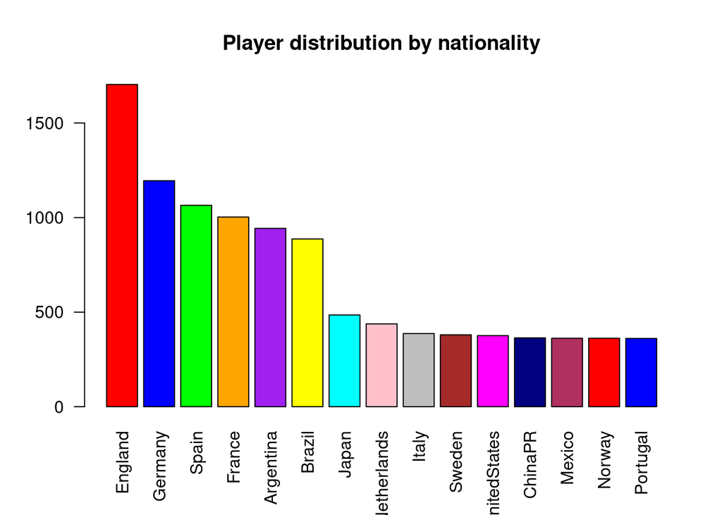

```r
library(ggplot2)
top_countries <- head(player_country_count , 15)
colors <- c("red", "blue", "green", "orange", "purple", "yellow", "cyan", "pink", "gray", "brown", "magenta", "navy", "maroon")

bar_plot <-barplot(top_countries , main ="Player distribution by nationality" , xlab = "" , ylab = "" , col = colors , las =2)
```

### Histogram by Age

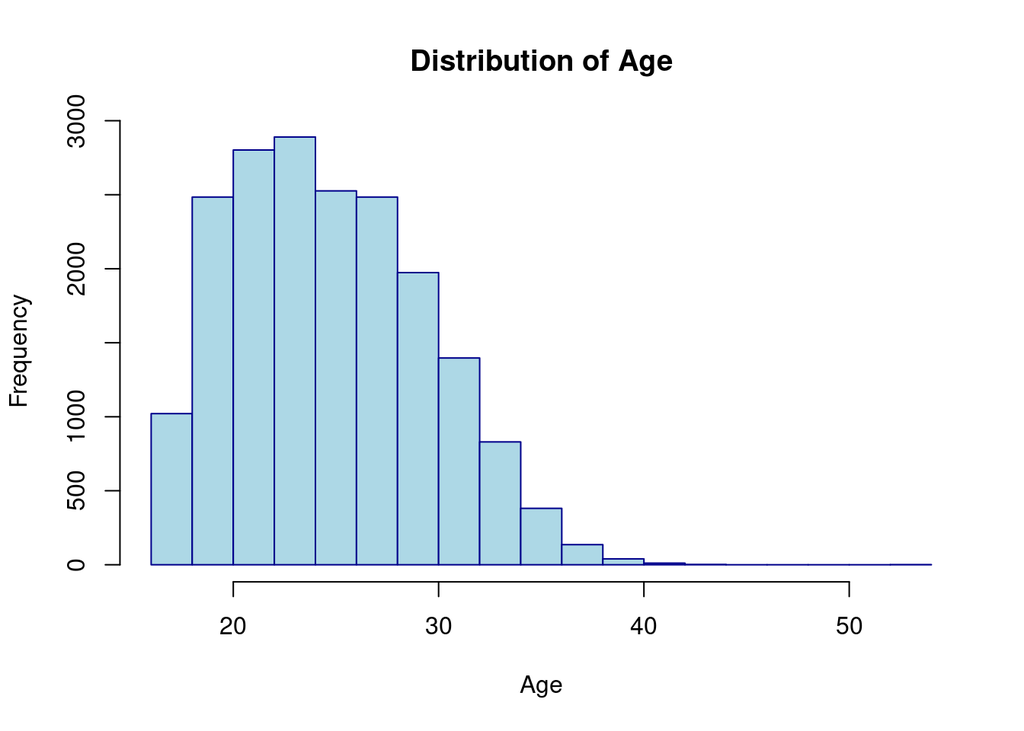

```r
df2$Age <- as.numeric(df2$Age)
hist(df2$Age, main = "Distribution of Age" , xlab = "Age" ,ylab = "Frequency" , col = "lightblue" , border = "darkblue")
```

### Scatterplot to compare “Overall rating” and “Value”

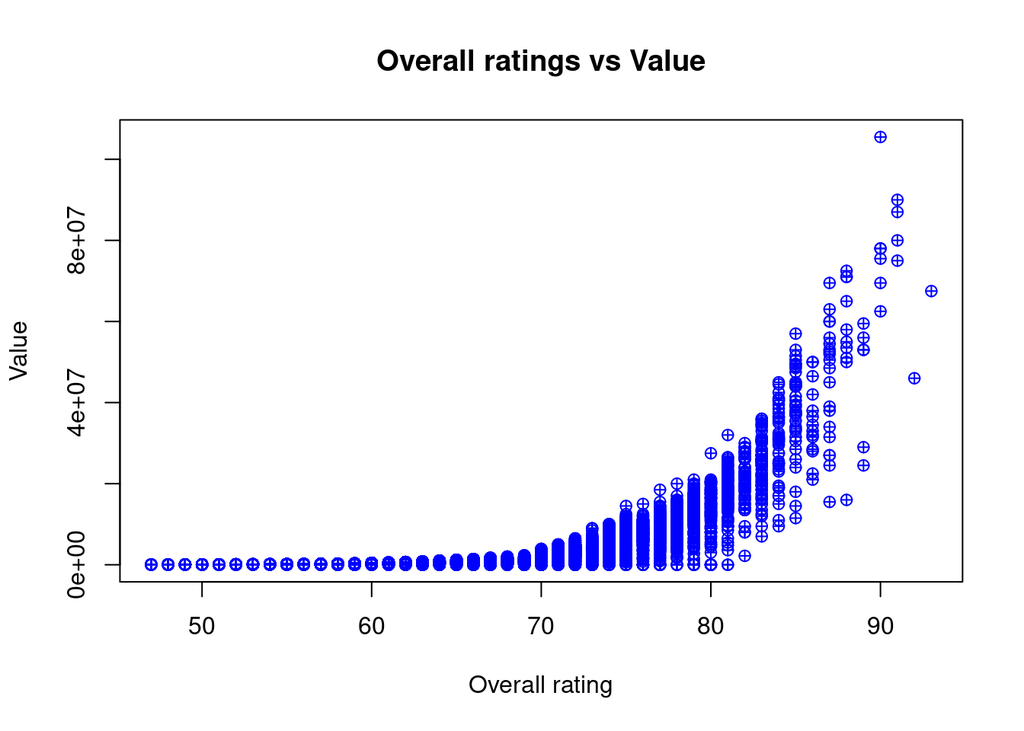

```r
max_value <- max(df2$Value, na.rm = TRUE)  # Find the maximum value

plot(df2$OVA , df2$Value ,main = "Overall ratings vs Value" , xlab = "Overall rating" , ylab = "Value" , col = "blue" , pch = 10 , ylim = c(0,max_value) )
```

### Pie chart representing left and right footed players

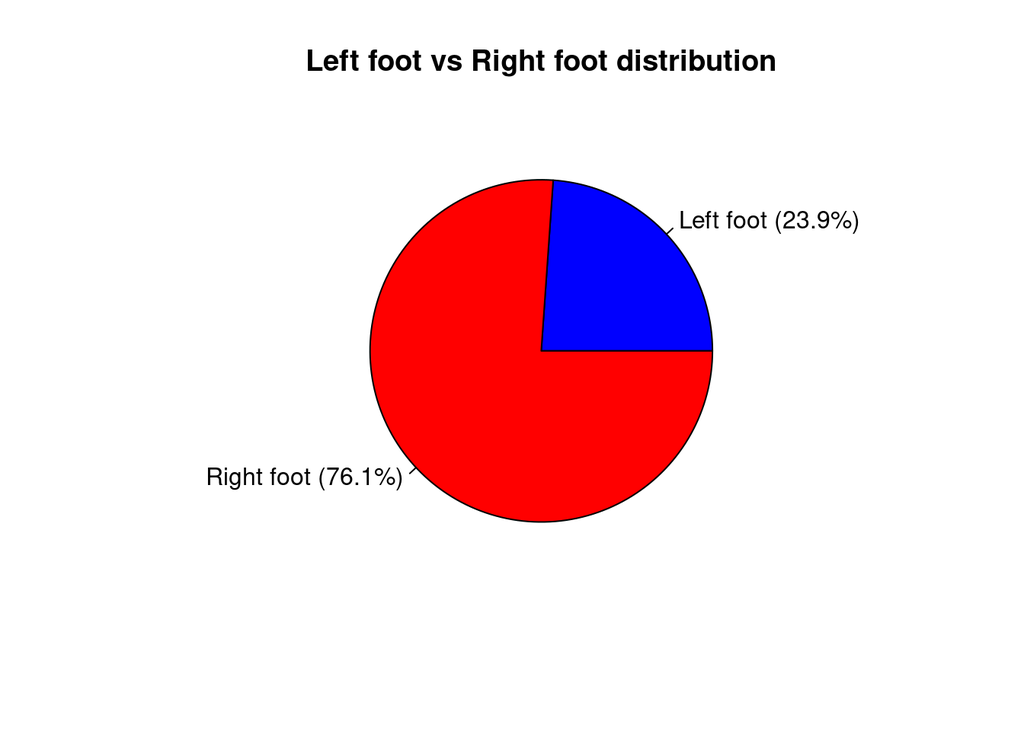

```r
labels <- c("Left foot" ,"Right foot")
values <- c(Left_foot , Right_foot)
colors <- c("blue","red")

pie(values, labels = paste(labels, paste0("(", round(values, 1), "%)")), col = colors , main = "Left foot vs Right foot distribution")
```

# Conclusion

In this analysis of the FIFA 21 dataset, we performed comprehensive data cleaning to ensure accuracy and usability. We removed unnecessary columns, converted height and weight into numeric format, cleaned columns with special characters, and transformed value and wage columns into numeric values.

After preparing the data, we explored various aspects of player information. We examined the country-wise distribution of players, analyzed the ratio of left and right-footed players, identified the tallest and fastest players, highlighted the best attackers and defenders, and discovered the strongest players. We also investigated the top paid and valuable players, identified undervalued players, and highlighted the best future prospects.

To visually represent the data, we created bar plots, histograms, scatterplots, and pie charts. These visualizations provided a clear understanding of player distribution, age distribution, overall ratings versus value, and the distribution of left and right-footed players.

This analysis offers valuable insights for football enthusiasts, data analysts, and industry recruiters. By exploring player attributes and market values, this analysis provides a deeper understanding of player characteristics and performance in the FIFA 21 dataset.